# Data Analysis Pipeline and Preliminary Results

Cuisine Authenticity and Taste

Author

Analysis Report

Published

August 2, 2026

## 1. Introduction

This report outlines the full data analysis pipeline for analyzing how respondents perceive the authenticity and ideal preparation of various cuisines. The core dependent variable asks respondents to rate 15 different cuisines on a 1-to-7 ordinal scale mapping onto concepts of authenticity and professionalization:

- **1** = A Traditional Recipe by an Elder at Home
- **4** = Neutral / Midpoint
- **7** = A Developed Recipe by a Professional Chef at a High-End Restaurant

The primary analytical goal is to evaluate how sociodemographic factors and ideological leanings (e.g., Social Conservatism) influence these perceptions across the rating scale.

## 2. Data Preparation and Reshaping

The data pipeline begins with raw survey data combining Qualtrics and Prolific samples.

1. **Recoding and Cleaning (`recode.dat.R`)**:
   - Demographic variables (age, education, income, gender, race) are cleaned and transformed into ordered/unordered factors (e.g., `educ.f`, `inc.f`) to act as fixed effects controls.
   - Ideological indices are constructed. Crucially, continuous predictors like **Social Conservatism (`social`)** are mean-centered (`social_c`). Centering ensures that the model intercepts represent the “average” survey respondent, which aids in convergence and interpretation.
2. **Long-Format Reshaping**:
   - To leverage multilevel modeling, the 15 separate cuisine rating columns are pivoted into a “long” dataset. Each row represents a single respondent’s rating of a single cuisine.
   - This structure allows the model to treat both `respondent_id` and `cuisine` as grouping variables (random effects), controlling for individual response tendencies and baseline differences between cuisines.

## 3. Modeling Strategy: Bayesian Adjacent Category (ACAT) Models

Because the outcome is a 1-to-7 ordinal scale, standard linear regression is inappropriate (it assumes the conceptual “distance” between a 1 and 2 is identical to a 6 and 7). Instead, we utilize **Bayesian Multilevel Ordinal Models** via the `brms` package.

We selected the **Adjacent Category (ACAT)** family. Unlike cumulative ordinal models (which predict the probability of rating *at least* a category), ACAT models predict the probability of choosing category $k+1$ rather than category $k$. This aligns conceptually with how survey respondents make step-by-step decisions on a Likert scale.

### Structural Model Hierarchy

To identify the optimal mathematical architecture for evaluating the data, we systematically fitted a hierarchy of six competing model specifications:

1. **Baseline Strict:** Assumes that continuous predictors (like mean-centered education and ideology) exert a uniform, linear push across all thresholds of the scale, identical for all cuisines.
2. **Relaxed Category-Specific (CS):** Relaxes the proportional odds assumption using the `cs()` specification (e.g., `cs(social_c)`). This allows the slope of predictors to vary across each step of the rating scale, capturing non-linear “centrist” or “polarizing” effects.
3. **Random Slopes (RS) Strict:** Returns to the strict linear structure but allows the effect of demographic predictors to vary independently for every cuisine.
4. **Relaxed CS + Random Slopes:** Combines both CS and RS structures.
5. **Variance Strict (Distributional):** Introduces a second equation predicting the `disc` parameter (inverse variance/consensus) using the same demographics, testing if groups differ in how much they agree on authenticity.
6. **Variance + Random Slopes:** The ultimate hybrid, applying cuisine-specific random slopes to both the location and the variance equations.

### Computational Optimizations

Given the massive complexity of these models (particularly ACAT location-scale formulations with random slopes), they require extreme computational efficiency to avoid Out-Of-Memory (OOM) crashes and endless sampling times. The pipeline utilizes: * **Fully Standardized Predictors:** All continuous predictors are centered and scaled (Mean = 0, SD = 1) to provide frictionless, “spherical” geometry for the NUTS sampler. * **`cmdstanr` Backend:** Completely bypasses R’s internal memory limits by executing the C++ binaries in an isolated background process. * **Within-Chain Threading (`reduce_sum`):** Uses `threads = threading(3)` to chunk the dataset and run likelihood calculations in parallel *within* each chain, fully saturating the server’s 12 CPU cores. * **Efficient Sampling:** The above optimizations allow convergence within a lean 2,000 iterations (1,000 warmup) while maintaining pristine Effective Sample Sizes (ESS).

## 4. Model Comparison

To determine which mathematical architecture is empirically justified, we compared their predictive performance using the **Watanabe-Akaike Information Criterion (WAIC)** subsetted to 1,000 random posterior draws (as standard LOO cross-validation matrices exceed available RAM).

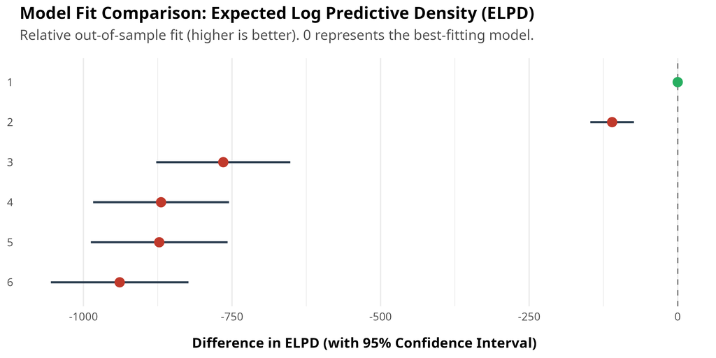

**Results:**

| Rank | Model Description | WAIC | SE | $\Delta$ WAIC (vs Baseline) |
| --- | --- | --- | --- | --- |
| **1** | **Variance + Random Slopes** | **53432.63** | 249.41 | **- 1877.96** |
| 2 | Variance Strict | 53653.40 | 249.42 | - 1657.19 |
| 3 | Relaxed CS + Random Slopes | 54961.97 | 244.84 | - 348.62 |
| 4 | Random Slopes Strict | 55171.37 | 243.27 | - 139.22 |
| 5 | Relaxed CS | 55177.51 | 243.10 | - 133.08 |
| 6 | Baseline Strict | 55310.59 | 241.69 | 0.00 |

- **Conclusion**:
  1. The **Distributional Variance models (5 & 6)** provide a massively superior fit ($\Delta$ WAIC > 1,600) over all standard location models, indicating that formally modeling the *variance* (consensus) of authenticity ratings is by far the most crucial architectural choice for this data.
  2. Among standard location models, adding **Random Slopes** (to allow cuisine-specific demographic effects) and **Category-Specific (CS) thresholds** yield moderate but meaningful improvements (-130 to -350 WAIC points) over the Strict Baseline.
  3. The best-fitting model overall combines Variance prediction with Random Slopes (`6_var_rs`).

## 5. Preliminary Findings: Baseline and Category-Specific Effects

### 5.1 Baseline Authenticity by Cuisine

In addition to fixed effects like ideology, the model estimates a random intercept for each of the 15 cuisines. This shows us the baseline public consensus for where each cuisine “belongs” on the authenticity-to-professionalization spectrum, holding demographic and ideological differences constant.

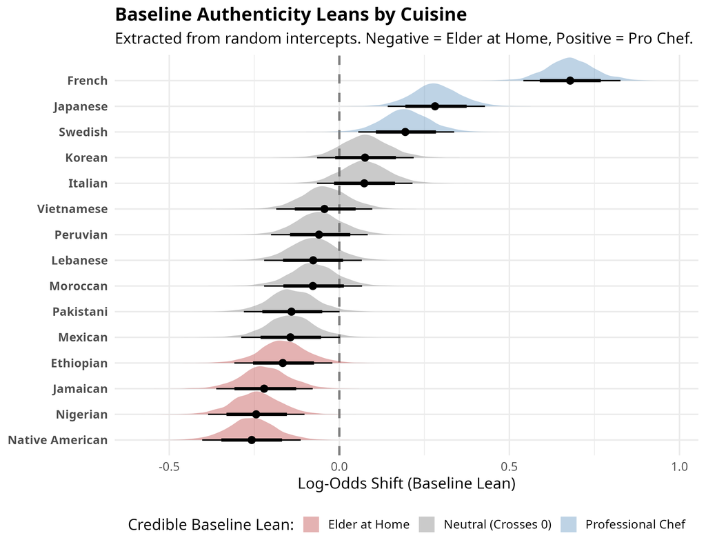

**Key Baseline Findings:** * **Most “Elder at Home”**: Native American, Nigerian, Jamaican, and Ethiopian cuisines have statistically credible negative intercepts, meaning the average respondent views them as most authentically prepared by a traditional elder at home. * **Most “Professional Chef”**: French, Japanese, and Swedish cuisines have strong positive intercepts, firmly rooting them in the high-end professional/chef domain in the public eye. (French cuisine is the most extreme outlier in this direction).

To interpret the non-linear Category-Specific (CS) effects from Model 2, we extracted the posterior draws for each threshold step (1|2, 2|3, …, 6|7) and mathematically recombined them into **contrasts against the neutral midpoint (4)**.

This allows us to visualize how a 1-standard-deviation increase in a given demographic trait shifts the probability of choosing an extreme rating relative to staying neutral.

### 5.2 Ideological Effects: Polarization vs. Centrism

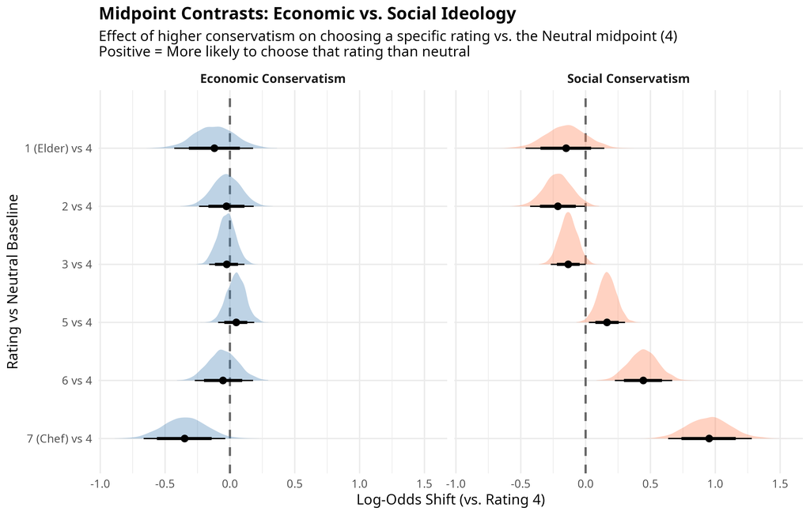

**Key Ideological Divergence:** * **Social Conservatism (Polarization)**: As social conservatism increases, respondents are wildly more likely to abandon the neutral midpoint for “7 - Professional Chef.” They are decisively drawn to the high-end, professional definition of authenticity. * **Economic Conservatism (Centrism)**: Economic conservatism exerts an anti-polarizing gravitational pull. Higher economic conservatism mathematically decreases the likelihood of choosing the extremes (“Professional Chef” or “Elder”) relative to the baseline. They pull inward toward the neutral baseline (4), avoiding extreme categorizations of cultural goods altogether.

To understand the mathematical mechanics driving these patterns, we can visualize the raw Category-Specific (CS) thresholds in the ACAT model. These represent the log-odds “push” across each internal boundary (e.g., the jump from Rating 6 to 7).

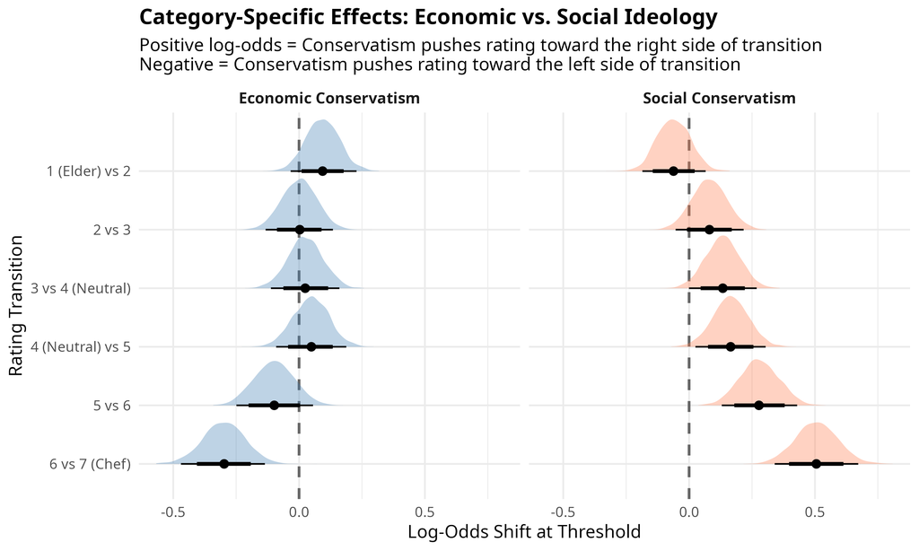

- **The Social Slingshot**: At the lower thresholds, the effect of Social Conservatism is muted. But at the final threshold (6 vs 7), it applies an enormous positive push (+0.51 log-odds), throwing respondents aggressively into the absolute extreme “Professional Chef” category.
- **The Economic Wall**: Economic conservatism weakly pushes people rightward away from 1 (+0.09). But crucially, at the upper thresholds (5 vs 6, and 6 vs 7), the coefficients flip negative (-0.10 and -0.30). This acts as a mathematical wall—blocking respondents from choosing extreme “Chef” ratings and trapping them in the middle of the scale.

### 5.3 Cultural Capital Effects

Concepts of “authenticity” and preference for “high-end chefs” versus “traditional elders” are heavily theorized as class-based (cultural capital).

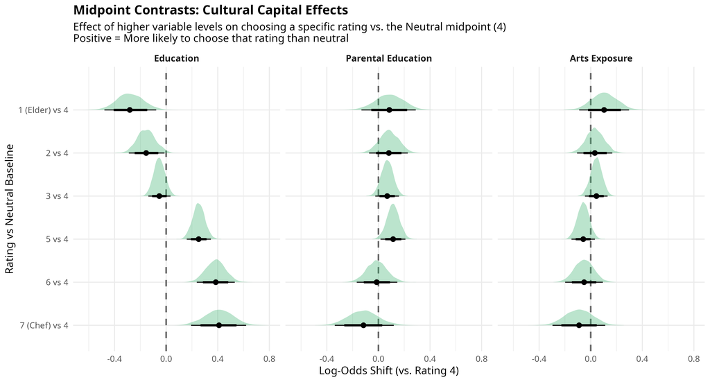

Again, looking at the raw internal category thresholds clarifies exactly how these two forms of capital diverge mathematically.

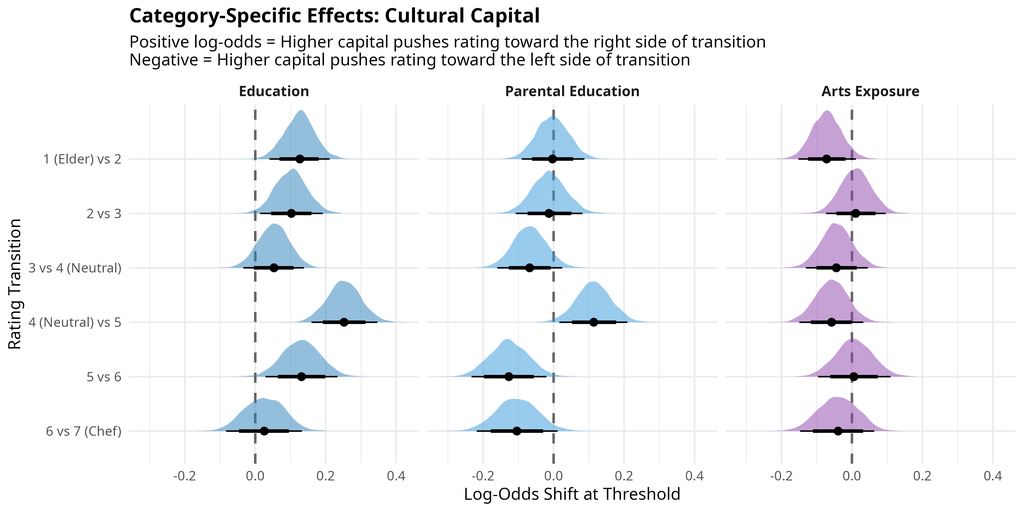

- **The Structural Plow**: A respondent’s own education applies a positive push at *every single threshold*. It functions like a snowplow, consistently shoving the respondent away from “Elder” and cleanly through the neutral midpoint toward the “Professional Chef” side of the scale.
- **The Restrained Centrist**: Inherited cultural capital (parental education) behaves almost exactly like Economic Conservatism. It exerts negative pressure at the upper thresholds (-0.12 at Threshold 5; -0.10 at Threshold 6). This prevents respondents from selecting extreme professionalization, suppressing extreme opinions in favor of a more restrained, moderate rating style.

## 6. Random Slopes: Demographic and Ideological Effects by Cuisine

We estimated a random slopes model (Model 3) allowing the continuous effects of Education, Parental Education, Social and Economic Conservatism, and Arts Exposure to vary independently for each cuisine. WAIC comparisons indicated this provided a statistically significant improvement in model fit, confirming that demographic and ideological factors interact with specific cuisines differently.

The following plots combine the global fixed effects with the cuisine-specific deviations (random slopes) to show the total structural push of each variable on each cuisine.

- A **negative slope** means that higher values of the variable pull that specific cuisine toward the “Traditional Elder at Home” (1) rating.
- A **positive slope** pushes it toward the “Professional Chef” (7) rating.

### 6.1 Ideological Effects

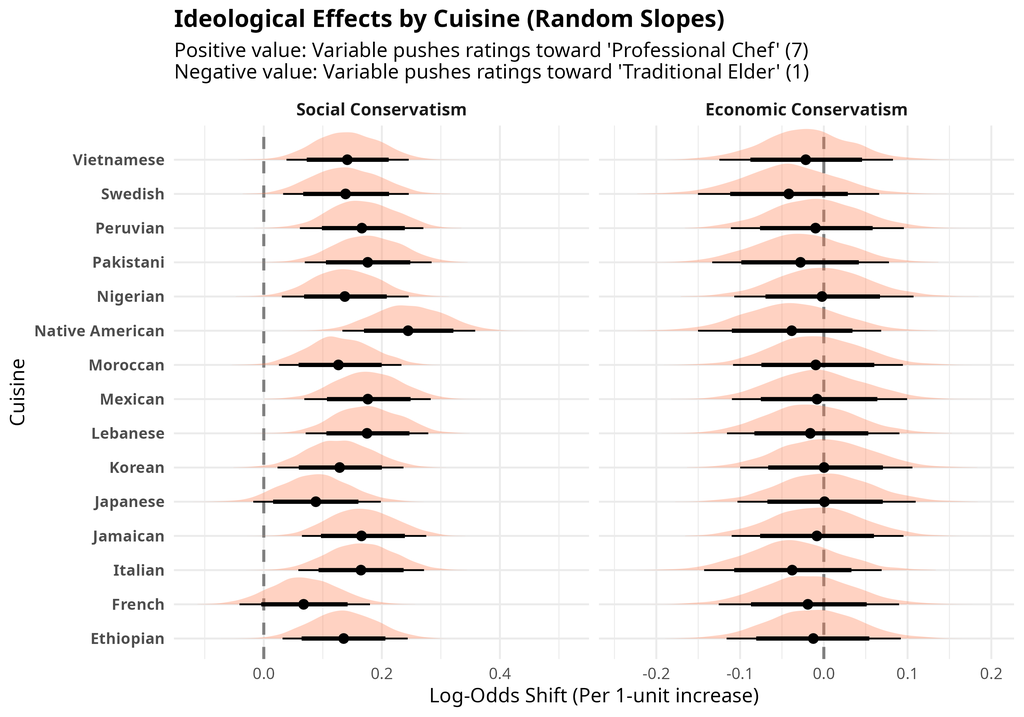

### 6.2 Cultural Capital Effects

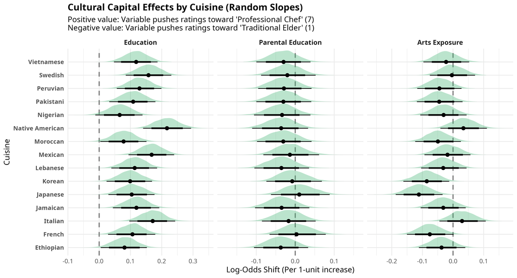

## 7. Cultural Consensus and Variance (Distributional Model)

To answer the question of whether there is widespread public agreement (consensus) vs. contestation (high variance) on these authenticity ratings, we fit a **Distributional (Location-Scale) ACAT Model**. This model simultaneously predicts both the core rating choice (location) and the precision or consensus of the responses (the `disc` parameter, which is the inverse of variance).

### 7.1 Baseline Variance by Cuisine

By extracting both the location intercept and the `disc` parameter intercept, we can map the entire authenticity landscape in two dimensions: where the cuisine sits, and how much the public agrees on it.

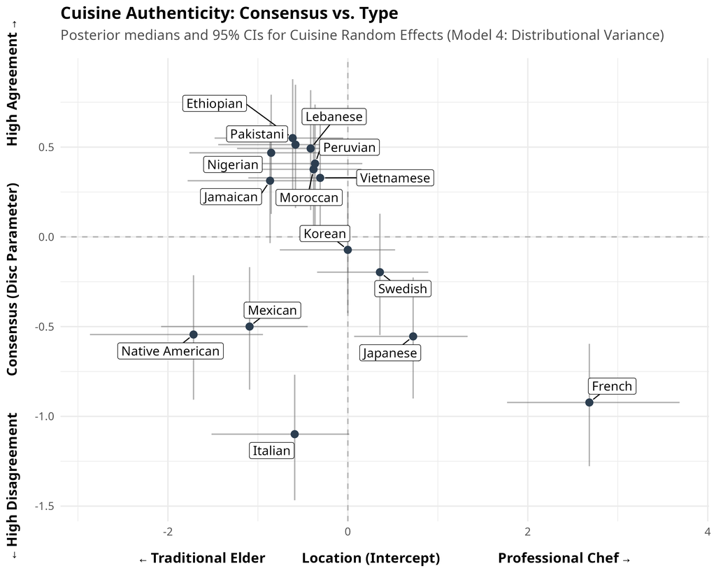

### 7.2 Demographic Effects on Global Consensus

Do certain demographic groups have stronger consensus than others? The following Bayesian “half-eye” forest plot visualizes the probability distribution of the demographic effects on the global `disc` (consensus) parameter.

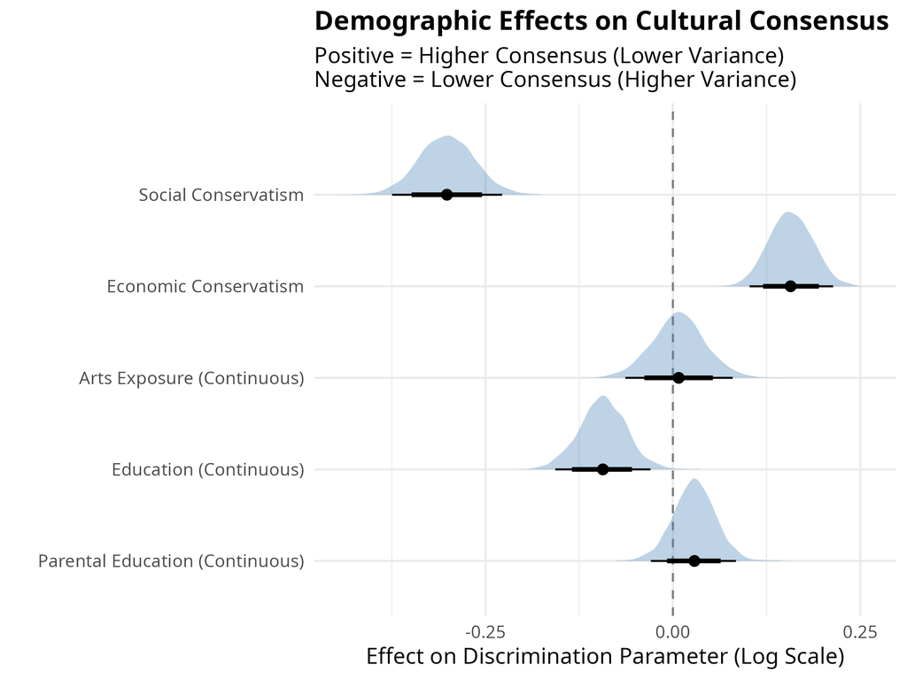

**Key Insights into Consensus:** * **Education Drives Dissensus:** Higher education levels firmly drop the discrimination parameter, meaning higher education results in wider variance (less consensus) on what constitutes authenticity globally. * **Ideological Chaos:** As social conservatism increases, the discrimination parameter also drops. Conservatives exhibit significantly higher variance (less consensus) in their authenticity ratings compared to liberals. * **Arts Exposure:** Childhood exposure to the arts does not have a statistically credible effect on variance, as its distribution widely crosses zero.

## 8. Random Slopes for Consensus: How Demographic Effects on Variance Change by Cuisine

Just as demographic pulls on the rating itself differ by cuisine, we also evaluated whether demographic impacts on *variance* differ by cuisine using Model 6 (Variance + Random Slopes).

- A **negative value** means the trait lowers consensus (increases variance/chaos) for that specific cuisine.
- A **positive value** means the trait increases consensus (decreases variance).

### 8.1 Ideological Effects on Consensus

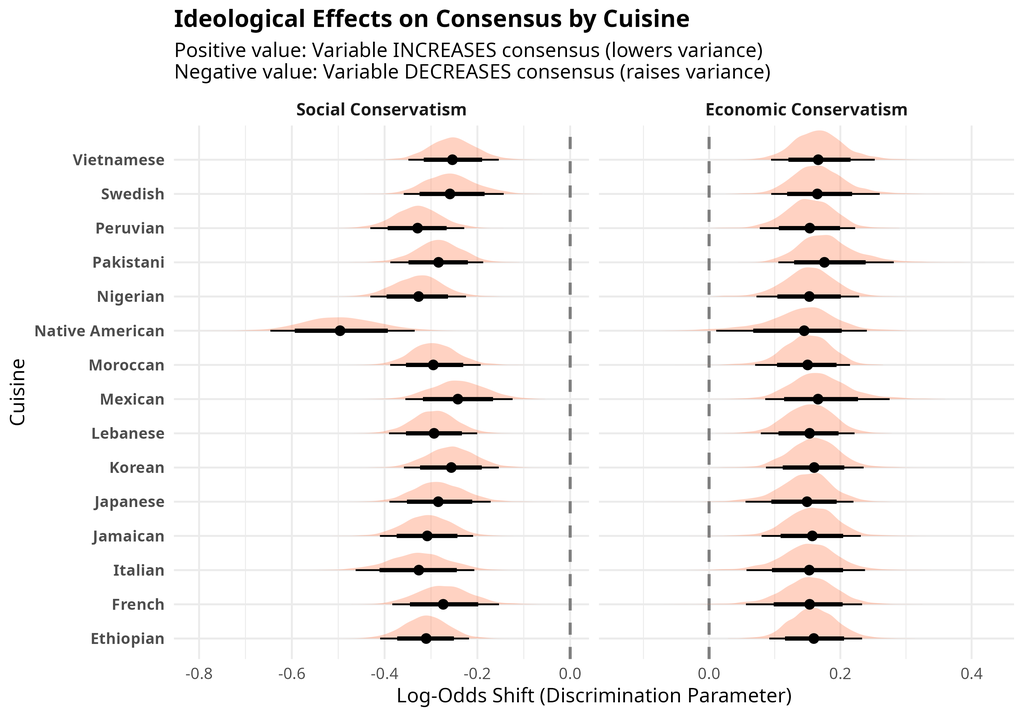

### 8.2 Cultural Capital Effects on Consensus

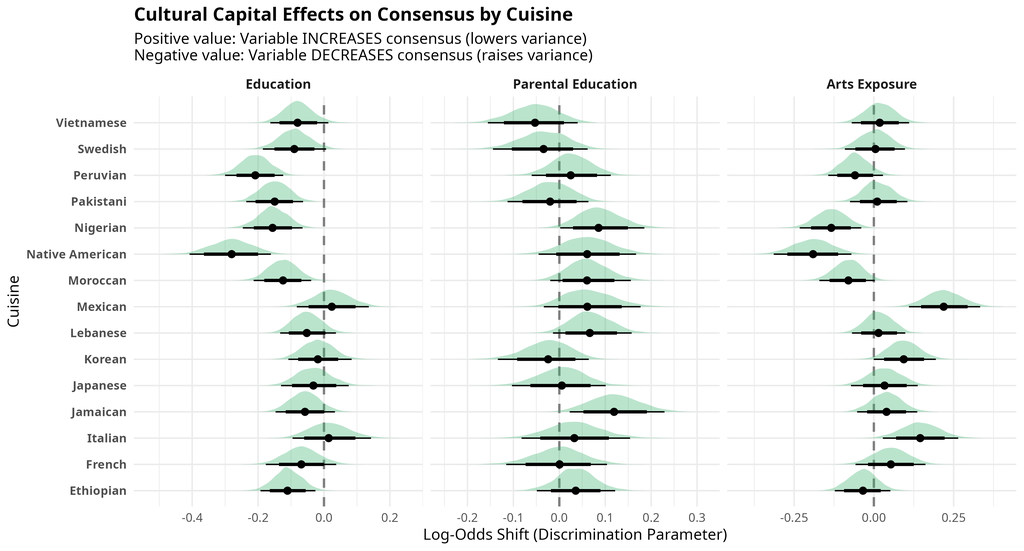